# Random Forest

Amruta

8/6/2019

- Clear Environment variables

```r
rm(list = ls(all = T))
```

- Load the required libraries

```r
library(DMwR)
library(randomForest)
library(caret)
```

- Read the data into R * since thr is no header given initially in the file, we give header

```r
data = read.table('hepatitis.txt', header=F, dec='.',
                  col.names=c('target','age','gender','steroid',
                              'antivirals','fatigue','malaise',
                              'anorexia','liverBig','liverFirm',
                              'spleen','spiders','ascites',
                              'varices','bili','alk','sgot',
                              'albu','protime','histology'),
                  na.strings=c('?'), sep=',')
```

- Understand the data

```r
str(data)
```

```
## 'data.frame':    155 obs. of  20 variables:
##  $ target    : int  2 2 2 2 2 2 1 2 2 2 ...
##  $ age       : int  30 50 78 31 34 34 51 23 39 30 ...
##  $ gender    : int  2 1 1 1 1 1 1 1 1 1 ...
##  $ steroid   : int  1 1 2 NA 2 2 1 2 2 2 ...
##  $ antivirals: int  2 2 2 1 2 2 2 2 2 2 ...
##  $ fatigue   : int  2 1 1 2 2 2 1 2 1 2 ...
##  $ malaise   : int  2 2 2 2 2 2 2 2 2 2 ...
##  $ anorexia  : int  2 2 2 2 2 2 1 2 2 2 ...
##  $ liverBig  : int  1 1 2 2 2 2 2 2 2 2 ...
##  $ liverFirm : int  2 2 2 2 2 2 2 2 1 2 ...
##  $ spleen    : int  2 2 2 2 2 2 1 2 2 2 ...
##  $ spiders   : int  2 2 2 2 2 2 1 2 2 2 ...
##  $ ascites   : int  2 2 2 2 2 2 2 2 2 2 ...
##  $ varices   : int  2 2 2 2 2 2 2 2 2 2 ...
##  $ bili      : num  1 0.9 0.7 0.7 1 0.9 NA 1 0.7 1 ...
##  $ alk       : int  85 135 96 46 NA 95 NA NA NA NA ...
##  $ sgot      : int  18 42 32 52 200 28 NA NA 48 120 ...
##  $ albu      : num  4 3.5 4 4 4 4 NA NA 4.4 3.9 ...
##  $ protime   : int  NA NA NA 80 NA 75 NA NA NA NA ...
##  $ histology : int  1 1 1 1 1 1 1 1 1 1 ...
```

```r
summary(data)
```

```
##      target           age           gender         steroid
##  Min.   :1.000   Min.   : 7.0   Min.   :1.000   Min.   :1.000
##  1st Qu.:2.000   1st Qu.:32.0   1st Qu.:1.000   1st Qu.:1.000
##  Median :2.000   Median :39.0   Median :1.000   Median :2.000
##  Mean   :1.794   Mean   :41.2   Mean   :1.103   Mean   :1.506
##  3rd Qu.:2.000   3rd Qu.:50.0   3rd Qu.:1.000   3rd Qu.:2.000
##  Max.   :2.000   Max.   :78.0   Max.   :2.000   Max.   :2.000
##                                                 NA's   :1
##    antivirals       fatigue         malaise         anorexia
##  Min.   :1.000   Min.   :1.000   Min.   :1.000   Min.   :1.000
##  1st Qu.:2.000   1st Qu.:1.000   1st Qu.:1.000   1st Qu.:2.000
##  Median :2.000   Median :1.000   Median :2.000   Median :2.000
##  Mean   :1.845   Mean   :1.351   Mean   :1.604   Mean   :1.792
##  3rd Qu.:2.000   3rd Qu.:2.000   3rd Qu.:2.000   3rd Qu.:2.000
##  Max.   :2.000   Max.   :2.000   Max.   :2.000   Max.   :2.000
##                  NA's   :1       NA's   :1       NA's   :1
##     liverBig       liverFirm         spleen       spiders
##  Min.   :1.000   Min.   :1.000   Min.   :1.0   Min.   :1.00
##  1st Qu.:2.000   1st Qu.:1.000   1st Qu.:2.0   1st Qu.:1.00
##  Median :2.000   Median :2.000   Median :2.0   Median :2.00
##  Mean   :1.828   Mean   :1.583   Mean   :1.8   Mean   :1.66
##  3rd Qu.:2.000   3rd Qu.:2.000   3rd Qu.:2.0   3rd Qu.:2.00
##  Max.   :2.000   Max.   :2.000   Max.   :2.0   Max.   :2.00
##  NA's   :10      NA's   :11      NA's   :5     NA's   :5
##     ascites         varices          bili            alk
##  Min.   :1.000   Min.   :1.00   Min.   :0.300   Min.   : 26.00
##  1st Qu.:2.000   1st Qu.:2.00   1st Qu.:0.700   1st Qu.: 74.25
##  Median :2.000   Median :2.00   Median :1.000   Median : 85.00
##  Mean   :1.867   Mean   :1.88   Mean   :1.428   Mean   :105.33
##  3rd Qu.:2.000   3rd Qu.:2.00   3rd Qu.:1.500   3rd Qu.:132.25
##  Max.   :2.000   Max.   :2.00   Max.   :8.000   Max.   :295.00
##  NA's   :5       NA's   :5      NA's   :6       NA's   :29
##       sgot             albu          protime         histology
##  Min.   : 14.00   Min.   :2.100   Min.   :  0.00   Min.   :1.000
##  1st Qu.: 31.50   1st Qu.:3.400   1st Qu.: 46.00   1st Qu.:1.000
##  Median : 58.00   Median :4.000   Median : 61.00   Median :1.000
##  Mean   : 85.89   Mean   :3.817   Mean   : 61.85   Mean   :1.452
##  3rd Qu.:100.50   3rd Qu.:4.200   3rd Qu.: 76.25   3rd Qu.:2.000
##  Max.   :648.00   Max.   :6.400   Max.   :100.00   Max.   :2.000
##  NA's   :4        NA's   :16      NA's   :67
```

- check target count 1: Die; 2: Live

```r
table(data$target)
```

```
##
##   1   2
##  32 123
```

```r
str(data$target)
```

```
##  int [1:155] 2 2 2 2 2 2 1 2 2 2 ...
```

- Convert 1s and 2s into 1s and 0s

```r
data$target= ifelse(data$target==1, 1, 0 )
```

- The numerical variables are: age, bili, alk, sgot, albu and protime The categorical variables are: the remaining 14 variables

```r
num_Attr = c("age", "bili", "alk", "sgot", "albu", "protime")
cat_Attr = setdiff(names(data), num_Attr)
```

- Seperate numerical and categorical variables and convert them into appropriate type

```r
cat_Data = data.frame(sapply(data[,cat_Attr], as.factor))
num_Data = data.frame(sapply(data[,num_Attr], as.numeric))
data = cbind(num_Data, cat_Data)
rm(num_Attr, cat_Attr)
rm(cat_Data, num_Data)
```

- Split dataset into train and test

```r
set.seed(9)

train_RowIDs = sample(1:nrow(data), nrow(data)*0.7)
train_Data = data[train_RowIDs,]
test_Data = data[-train_RowIDs,]
rm(train_RowIDs)
```

- Check how records are split with respect to target attribute.

```r
table(data$target)
```

```
##
##   0   1
## 123  32
```

```r
table(train_Data$target)
```

```
##
##  0  1
## 86 22
```

```r
table(test_Data$target)
```

```
##
##  0  1
## 37 10
```

```r
rm(data)
```

```r
sum(is.na(train_Data))
```

```
## [1] 111
```

```r
sum(is.na(test_Data))
```

```
## [1] 56
```

- Imputing missing values using KNN

```r
train_Data <- knnImputation(data = train_Data, k = 5)
sum(is.na(train_Data))
```

```
## [1] 0
```

```r
test_Data <- knnImputation(data = test_Data, k = 5, distData = train_Data)
sum(is.na(test_Data))
```

```
## [1] 0
```

- Model Building

  Build the classification model using randomForest

```r
set.seed(123)

model = randomForest(target ~ ., data=train_Data,
                     keep.forest=TRUE, ntree=100)
```

- Print and understand the model

```r
print(model)
```

```
##
## Call:
##  randomForest(formula = target ~ ., data = train_Data, keep.forest = TRUE,      ntree = 100)
##                Type of random forest: classification
##                      Number of trees: 100
## No. of variables tried at each split: 4
##
##         OOB estimate of  error rate: 13.89%
## Confusion matrix:
##    0  1 class.error
## 0 81  5  0.05813953
## 1 10 12  0.45454545
```

- Important attributes

```r
model$importance
```

```
##            MeanDecreaseGini
## age               2.0898625
## bili              4.1846822
## alk               3.5390781
## sgot              2.3724963
## albu              4.9331590
## protime           7.1518156
## gender            0.7220741
## steroid           0.4687137
## antivirals        0.1387166
## fatigue           0.1756816
## malaise           0.7124207
## anorexia          0.4187839
## liverBig          0.2793672
## liverFirm         0.3585050
## spleen            0.4342540
## spiders           1.5699996
## ascites           2.0945493
## varices           0.4505649
## histology         1.3847994
```

```r
round(importance(model), 2)
```

```
##            MeanDecreaseGini
## age                    2.09
## bili                   4.18
## alk                    3.54
## sgot                   2.37
## albu                   4.93
## protime                7.15
## gender                 0.72
## steroid                0.47
## antivirals             0.14
## fatigue                0.18
## malaise                0.71
## anorexia               0.42
## liverBig               0.28
## liverFirm              0.36
## spleen                 0.43
## spiders                1.57
## ascites                2.09
## varices                0.45
## histology              1.38
```

- Extract and store important variables obtained from the random forest model

```r
rf_Imp_Attr = data.frame(model$importance)
rf_Imp_Attr = data.frame(row.names(rf_Imp_Attr),rf_Imp_Attr[,1])
colnames(rf_Imp_Attr) = c('Attributes', 'Importance')
rf_Imp_Attr = rf_Imp_Attr[order(rf_Imp_Attr$Importance, decreasing = TRUE),]
```

- plot (directly prints the important attributes)

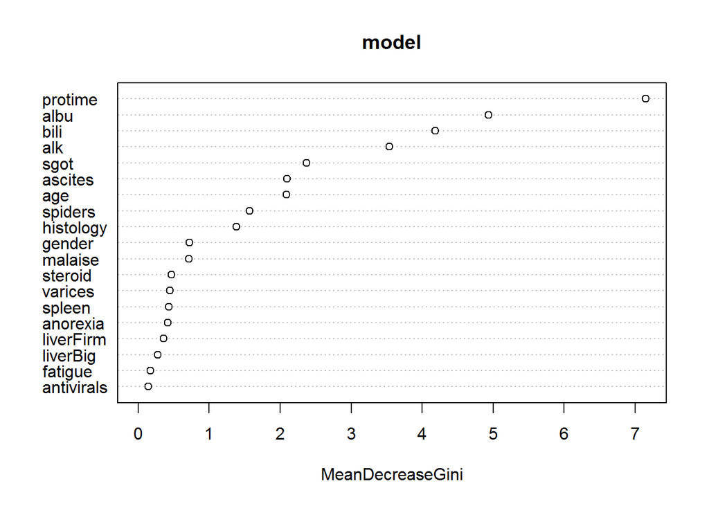

```r
varImpPlot(model)
```

- Predict on Train data ’

```r
pred_Train = predict(model,
                     train_Data[,setdiff(names(train_Data), "target")],
                     type="vote",
                     norm.votes=TRUE)

pred_Train = predict(model,
                     train_Data[,setdiff(names(train_Data), "target")],
                     type="response",
                     norm.votes=TRUE) #normalize the response
```

- Build confusion matrix and find accuracy

```r
cm_Train = table("actual"= train_Data$target, "predicted" = pred_Train);
accu_Train= sum(diag(cm_Train))/sum(cm_Train)
rm(pred_Train, cm_Train)
```

- Predicton Test Data

```r
pred_Test = predict(model, test_Data[,setdiff(names(test_Data),
                                              "target")],
                    type="response",
                    norm.votes=TRUE)
```

- Build confusion matrix and find accuracy

```r
cm_Test = table("actual"=test_Data$target, "predicted"=pred_Test);
accu_Test= sum(diag(cm_Test))/sum(cm_Test)
rm(pred_Test, cm_Test)

accu_Train
```

```
## [1] 1
```

```r
accu_Test
```

```
## [1] 0.893617
```

```r
top_Imp_Attr = as.character(rf_Imp_Attr$Attributes[1:12])

set.seed(15)
```

- Build the classification model using randomForest

```r
model_Imp = randomForest(target~.,
                         data=train_Data[,c(top_Imp_Attr,"target")],
                         keep.forest=TRUE,ntree=100)
```

- Print and understand the model

```r
print(model_Imp)
```

```
##
## Call:
##  randomForest(formula = target ~ ., data = train_Data[, c(top_Imp_Attr,      "target")], keep.forest = TRUE, ntree = 100)
##                Type of random forest: classification
##                      Number of trees: 100
## No. of variables tried at each split: 3
##
##         OOB estimate of  error rate: 15.74%
## Confusion matrix:
##    0  1 class.error
## 0 79  7  0.08139535
## 1 10 12  0.45454545
```

- Important attributes

```r
model_Imp$importance
```

```
##           MeanDecreaseGini
## protime          8.7399526
## albu             5.5864072
## bili             4.5227133
## alk              3.8325579
## sgot             2.4985216
## ascites          1.9124204
## age              2.1395198
## spiders          2.5262177
## histology        1.1965142
## gender           0.7350905
## malaise          0.6045107
## steroid          0.3702036
```

- Predict on Train data

```r
pred_Train = predict(model_Imp, train_Data[,top_Imp_Attr],
                     type="response", norm.votes=TRUE)
```

- Build confusion matrix and find accuracy

```r
cm_Train = table("actual" = train_Data$target,
                 "predicted" = pred_Train);
accu_Train_Imp = sum(diag(cm_Train))/sum(cm_Train)
rm(pred_Train, cm_Train)
```

- Predicton Test Data

```r
pred_Test = predict(model_Imp, test_Data[,top_Imp_Attr],
                    type="response", norm.votes=TRUE)
```

- Build confusion matrix and find accuracy

```r
cm_Test = table("actual" = test_Data$target,
                "predicted" = pred_Test);
accu_Test_Imp = sum(diag(cm_Test))/sum(cm_Test)
rm(pred_Test, cm_Test)

accu_Train
```

```
## [1] 1
```

```r
accu_Test
```

```
## [1] 0.893617
```

```r
accu_Train_Imp
```

```
## [1] 1
```

```r
accu_Test_Imp
```

```
## [1] 0.8723404
```

- Select mtry value with minimum out of bag(OOB) error. selection of number of features.

```
## mtry = 4  OOB error = 14.81%
## Searching left ...
## mtry = 3     OOB error = 10.19%
## 0.3125 0.01
## mtry = 2     OOB error = 12.96%
## -0.2727273 0.01
## Searching right ...
## mtry = 6     OOB error = 12.04%
## -0.1818182 0.01
```

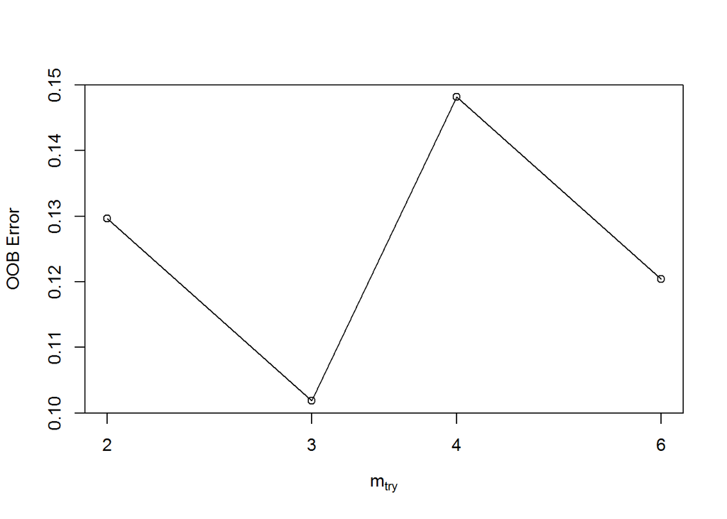

```r
mtry <- tuneRF(train_Data[-7],train_Data$target, ntreeTry=100,
               stepFactor=1.5,improve=0.01, trace=TRUE, plot=TRUE)
```

- how many step u need to jump while selecting features * if u dont see impruvement by given value stop.

```r
best.m <- mtry[mtry[, 2] == min(mtry[, 2]), 1]
print(mtry)
```

```
##       mtry  OOBError
## 2.OOB    2 0.1296296
## 3.OOB    3 0.1018519
## 4.OOB    4 0.1481481
## 6.OOB    6 0.1203704
```

```r
print(best.m)
```

```
## [1] 3
```

- Build Model with best mtry again -

```r
set.seed(71)
rf <- randomForest(target~.,data=train_Data, mtry=best.m, importance=TRUE,ntree=100)
print(rf)
```

```
##
## Call:
##  randomForest(formula = target ~ ., data = train_Data, mtry = best.m,      importance = TRUE, ntree = 100)
##                Type of random forest: classification
##                      Number of trees: 100
## No. of variables tried at each split: 3
##
##         OOB estimate of  error rate: 13.89%
## Confusion matrix:
##    0  1 class.error
## 0 80  6  0.06976744
## 1  9 13  0.40909091
```

- Evaluate variable importance

```r
importance(rf)
```

```
##                      0            1 MeanDecreaseAccuracy MeanDecreaseGini
## age        -0.90847690  3.049165178           1.45495595        2.4060185
## bili        1.19852883  3.180897916           2.59049214        3.9943779
## alk         1.90678921  0.781111844           1.94151694        3.3323581
## sgot       -0.02208594  0.121206399           0.07351461        2.3941219
## albu        1.51311390  5.429883858           4.41721064        5.5702561
## protime     2.82650761  7.512726953           6.63378207        7.1685898
## gender      1.82090091  2.890843869           2.95255171        0.4614974
## steroid    -1.04732349  0.338098000          -0.62262078        0.6179245
## antivirals -0.62395946 -1.428571429          -1.03850828        0.2350340
## fatigue    -1.31972846  3.167689425           1.23477616        0.7232013
## malaise     0.18238767  1.197008302           0.58390386        0.3670238
## anorexia    0.46173020 -0.698516050          -0.26624999        0.3022923
## liverBig    2.32772765 -0.007226617           2.27555733        0.4978907
## liverFirm  -0.00545758  0.456381618           0.37767353        0.4069090
## spleen     -1.27741685  1.297845921          -0.63148312        0.7209950
## spiders     2.15590808  4.935303286           4.81221568        1.9162654
## ascites     1.13304464  3.734382752           3.14446031        2.0990166
## varices    -0.29753976  1.841431203           1.32992475        0.6575656
## histology  -1.06377134  1.509813768           0.63435596        1.2360508
```

- Important attributes

```r
model$importance
```

```
##            MeanDecreaseGini
## age               2.0898625
## bili              4.1846822
## alk               3.5390781
## sgot              2.3724963
## albu              4.9331590
## protime           7.1518156
## gender            0.7220741
## steroid           0.4687137
## antivirals        0.1387166
## fatigue           0.1756816
## malaise           0.7124207
## anorexia          0.4187839
## liverBig          0.2793672
## liverFirm         0.3585050
## spleen            0.4342540
## spiders           1.5699996
## ascites           2.0945493
## varices           0.4505649
## histology         1.3847994
```

```r
round(importance(model), 2)
```

```
##            MeanDecreaseGini
## age                    2.09
## bili                   4.18
## alk                    3.54
## sgot                   2.37
## albu                   4.93
## protime                7.15
## gender                 0.72
## steroid                0.47
## antivirals             0.14
## fatigue                0.18
## malaise                0.71
## anorexia               0.42
## liverBig               0.28
## liverFirm              0.36
## spleen                 0.43
## spiders                1.57
## ascites                2.09
## varices                0.45
## histology              1.38
```

- Extract and store important variables obtained from the random forest model

```r
rf_Imp_Attr = data.frame(model$importance)
rf_Imp_Attr = data.frame(row.names(rf_Imp_Attr),rf_Imp_Attr[,1])
colnames(rf_Imp_Attr) = c('Attributes', 'Importance')
rf_Imp_Attr = rf_Imp_Attr[order(rf_Imp_Attr$Importance, decreasing = TRUE),]
```

- Predict on Train data

```r
pred_Train = predict(model,
                     train_Data[,setdiff(names(train_Data), "target")],
                     type="response",
                     norm.votes=TRUE)
```

- Build confusion matrix and find accuracy

```r
cm_Train = table("actual"= train_Data$target, "predicted" = pred_Train);
accu_Train = sum(diag(cm_Train))/sum(cm_Train)
rm(pred_Train, cm_Train)
```

- Predicton Test Data

```r
pred_Test = predict(model, test_Data[,setdiff(names(test_Data),
                                              "target")],
                    type="response",
                    norm.votes=TRUE)
```

- Build confusion matrix and find accuracy

```r
cm_Test = table("actual"=test_Data$target, "predicted"=pred_Test);
accu_Test= sum(diag(cm_Test))/sum(cm_Test)
rm(cm_Test)

accu_Train
```

```
## [1] 1
```

```r
accu_Test
```

```
## [1] 0.893617
```

Note: You can find data at : "http://archive.ics.uci.edu/ml/datasets/Hepatitis